# User Guide

### From ‘pavo’

In this example we convert an `rspec` object from package ‘pavo’ into a collection of spectra and then we plot it with `ggplot` methods from package `ggspectra' (an extension to`ggplot2’). The data are the spectral reflectance of the plumage from seven different individual birds of the same species, measured in three different body parts.

```r
data(sicalis)
class(sicalis)
```

```
## [1] "rspec"      "data.frame"
```

```r
names(sicalis)
```

```
##  [1] "wl"     "ind1.C" "ind1.T" "ind1.B" "ind2.C"
##  [6] "ind2.T" "ind2.B" "ind3.C" "ind3.T" "ind3.B"
## [11] "ind4.C" "ind4.T" "ind4.B" "ind5.C" "ind5.T"
## [16] "ind5.B" "ind6.C" "ind6.T" "ind6.B" "ind7.C"
## [21] "ind7.T" "ind7.B"
```

We convert the data into a collection of spectra, and calculate summaries for three spectra.

```r
sicalis.mspct <- rspec2mspct(sicalis, "reflector_spct", "Rpc")
summary(sicalis.mspct[[1]])
```

```
## Summary of reflector_spct [401 x 2] object: anonymous
## Wavelength range 300-700 nm, step 1 nm
## Variables:
##  w.length: Wavelength [nm]
##  Rfr: Total spectral reflectance [/1]
## --
##     w.length        Rfr
##  Min.   :300   Min.   :0.001798
##  1st Qu.:400   1st Qu.:0.008288
##  Median :500   Median :0.031709
##  Mean   :500   Mean   :0.052848
##  3rd Qu.:600   3rd Qu.:0.098775
##  Max.   :700   Max.   :0.114807
```

```r
summary(sicalis.mspct[[2]])
```

```
## Summary of reflector_spct [401 x 2] object: anonymous
## Wavelength range 300-700 nm, step 1 nm
## Variables:
##  w.length: Wavelength [nm]
##  Rfr: Total spectral reflectance [/1]
## --
##     w.length        Rfr
##  Min.   :300   Min.   :0.006783
##  1st Qu.:400   1st Qu.:0.030112
##  Median :500   Median :0.096994
##  Mean   :500   Mean   :0.105449
##  3rd Qu.:600   3rd Qu.:0.179691
##  Max.   :700   Max.   :0.183823
```

```r
summary(sicalis.mspct[[3]])
```

```
## Summary of reflector_spct [401 x 2] object: anonymous
## Wavelength range 300-700 nm, step 1 nm
## Variables:
##  w.length: Wavelength [nm]
##  Rfr: Total spectral reflectance [/1]
## --
##     w.length        Rfr
##  Min.   :300   Min.   :0.001191
##  1st Qu.:400   1st Qu.:0.022293
##  Median :500   Median :0.085235
##  Mean   :500   Mean   :0.116253
##  3rd Qu.:600   3rd Qu.:0.212554
##  Max.   :700   Max.   :0.224162
```

We convert the subset of the collection corresponding to the first individual into a single spectra object for plotting with `ggplot`.

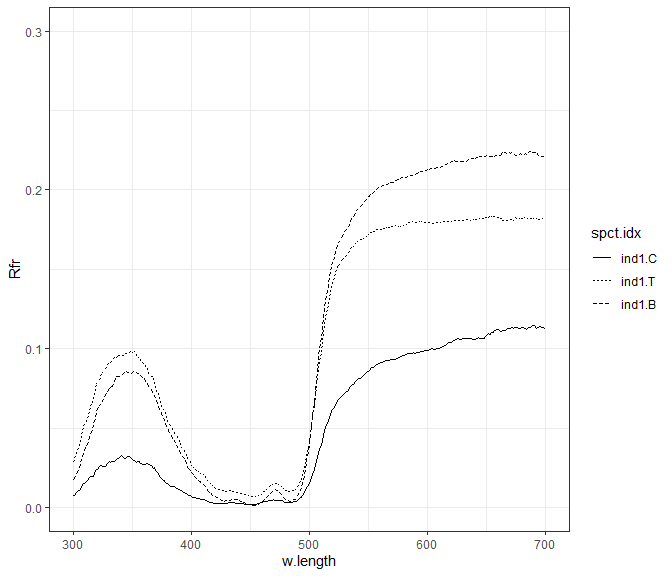

```r
ggplot(rbindspct(sicalis.mspct[1:3])) +
  aes(linetype = spct.idx) +
  ylim(0,0.3) +
  geom_line()
```

Here we extract the ``crown’’ data from all individuals and plot these spectra in a single plot.

```r
print(sicalis.mspct[c(TRUE, FALSE, FALSE)])
```

```
## Object: reflector_mspct [7 x 1]
## --- Member: ind1.C ---
## Object: reflector_spct [401 x 2]
## Wavelength range 300-700 nm, step 1 nm
## Variables:
##  w.length: Wavelength [nm]
##  Rfr: Total spectral reflectance [/1]
## --
## # A tibble: 401 × 2
##   w.length     Rfr
##      <int>   <dbl>
## 1      300 0.00759
## 2      301 0.00773
## 3      302 0.00829
## # ℹ 398 more rows
## --- Member: ind2.C ---
## Object: reflector_spct [401 x 2]
## Wavelength range 300-700 nm, step 1 nm
## Variables:
##  w.length: Wavelength [nm]
##  Rfr: Total spectral reflectance [/1]
## --
## # A tibble: 401 × 2
##   w.length     Rfr
##      <int>   <dbl>
## 1      300 0.00297
## 2      301 0.00233
## 3      302 0.00323
## # ℹ 398 more rows
## --- Member: ind3.C ---
## Object: reflector_spct [401 x 2]
## Wavelength range 300-700 nm, step 1 nm
## Variables:
##  w.length: Wavelength [nm]
##  Rfr: Total spectral reflectance [/1]
## --
## # A tibble: 401 × 2
##   w.length      Rfr
##      <int>    <dbl>
## 1      300 0.000595
```

[output cut: 46 more lines]

```
## Object: reflector_spct [401 x 2]
## Wavelength range 300-700 nm, step 1 nm
## Variables:
##  w.length: Wavelength [nm]
##  Rfr: Total spectral reflectance [/1]
## --
## # A tibble: 401 × 2
##   w.length     Rfr
##      <int>   <dbl>
## 1      300 0.00168
## 2      301 0.00104
## 3      302 0.00170
## # ℹ 398 more rows
##
## --- END ---
```

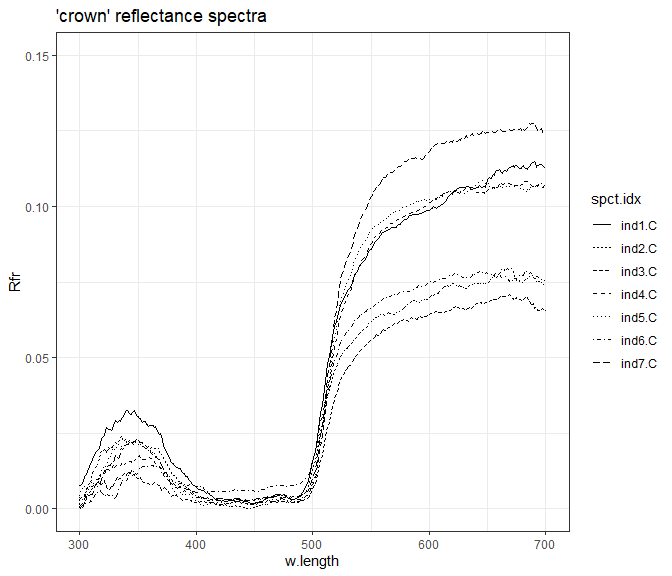

```r
ggplot(rbindspct(sicalis.mspct[c(TRUE, FALSE, FALSE)])) +
  aes(linetype = spct.idx) +
  ylim(0,0.15) +
  geom_line() +
  ggtitle("'crown' reflectance spectra")
```

We calculate the mean reflectance in wavebands corresponding to ISO colors obtaining a data frame. We then add to this returned data frame a factor indicating the body parts.

```r
refl.by.band <- reflectance(sicalis.mspct, w.band = list(Red(), Green(), Blue(), UVA()))
refl.by.band$body.part <- rep(c("crown", "throat", "breast"), 7)
```

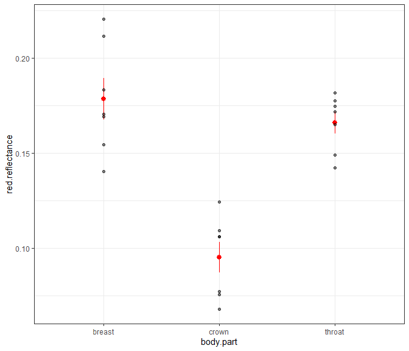

```r
refl.red <- reflectance(sicalis.mspct, w.band = Red())
names(refl.red)[2] <- "red.reflectance"
refl.red$body.part <- rep(c("crown", "throat", "breast"), 7)
ggplot(refl.red, aes(x = body.part, y = red.reflectance)) +
  stat_summary(fun.data = "mean_se", color = "red") +
  geom_point(alpha = 0.5)
```

## Dealing with odd and bad data

### Using locales

Most functions in this package have a parameter `locale`, that accepts `readr::locale` objects as arguments. At the moment only the time zone and decimal mark are respected. This allows files using comma for decimal marker be easily imported, or the dates and times **in the input file** be interpreted in a given time zone. Setting the correct time zone is very important to avoid errors. Time coordinates are always stored in the created objects using universal time coordinates (“UTC”).

```r
jaz.irrad.comma.file <-
  system.file("extdata", "spectrum-comma.JazIrrad",
              package = "photobiologyInOut", mustWork = TRUE)
my.locale <- locale(decimal_mark = ",", tz = "Europe/Helsinki")
jaz00.spct <- read_oo_jazirrad(file = jaz.irrad.comma.file,
                               locale = my.locale)
```

```r
jaz00.spct
```

```
## Object: source_spct [2,048 x 2]
## Wavelength range 188.82523-1033.1483 nm, step 0.357056-0.459625 nm
## Label: File: spectrum-comma.JazIrrad
## Measured on 2015-02-03 07:44:41 UTC
## Variables:
##  w.length: Wavelength [nm]
##  s.e.irrad: Spectral energy irradiance [W m-2 nm-1]
## --
## # A tibble: 2,048 × 2
##   w.length s.e.irrad
##      <dbl>     <dbl>
## 1     189.         0
## 2     189.         0
## 3     190.         0
## # ℹ 2,045 more rows
```

### Overriding default metadata

We revisit now the Jaz irradiance data to show how the metadata can be changed by the user if needed (e.g. clock settings at the time of data acquisition were wrong).

A variable with the user supplied date and time data, or the date read from the header (the text itself) not the file date as the file date may not reflect the creation date and time.

```r
jaz.s.irrad.file <-
  system.file("extdata", "spectrum.JazIrrad",
              package = "photobiologyInOut", mustWork = TRUE)
```

```r
jaz01.spct <- read_oo_jazirrad(file = jaz.s.irrad.file,
                               date = NULL)
when_measured(jaz01.spct)
```

```
## [1] "2015-02-03 09:44:41 UTC"
```

```r
jaz02.spct <- read_oo_jazirrad(file = jaz.s.irrad.file,
                               date = ymd_hms("2015-11-15 12:00:00"))
when_measured(jaz02.spct)
```

```
## [1] "2015-11-15 12:00:00 UTC"
```

```r
jaz03.spct <- read_oo_jazirrad(file = jaz.s.irrad.file,
                               date = now())
when_measured(jaz03.spct)
```

```
## [1] "2025-09-24 17:53:41 UTC"
```

### Adding additional metadata

```r
my.geocode <- data.frame(lon = 25.02006, lat = 60.22525)
jaz04.spct <- read_oo_jazirrad(file = jaz.s.irrad.file,
                               geocode = my.geocode)
jaz04.spct
```

```
## Object: source_spct [2,048 x 2]
## Wavelength range 188.82523-1033.1483 nm, step 0.357056-0.459625 nm
## Label: File: spectrum.JazIrrad
## Measured on 2015-02-03 09:44:41 UTC
## Variables:
##  w.length: Wavelength [nm]
##  s.e.irrad: Spectral energy irradiance [W m-2 nm-1]
## --
## # A tibble: 2,048 × 2
##   w.length s.e.irrad
##      <dbl>     <dbl>
## 1     189.         0
## 2     189.         0
## 3     190.         0
## # ℹ 2,045 more rows
```

```r
where_measured(jaz04.spct)
```

```
## # A tibble: 1 × 3
##     lon   lat address
##   <dbl> <dbl> <chr>
## 1  25.0  60.2 <NA>
```